# DS 202 Final Project Team 8 Report

# Visualizing the Data

Visualizing the data was a fairly straight-forward process. We started by looking at each of the questions we wanted answered and tried to determine from that which type of plot/visualization would work best to answer it. Once we had this step done, we attempted to create these visualizations in R. Some of these worked better than others. Others proved to be very difficult.

Using county data, for example, finding crash rates by county was very tough. This was because there are multiple counties in the United States who have the same name, and with the dataset we chose for county population, there was no way to see which county belonged to which state. In addition, certain counties had multiple rows with competing population figures. This meant we would have to take the mean of these numbers to find the population to use, but once again, there was no way to know which county was which, so we were not able to group by county name to find this. As a result, we had to change our questions to focus purely on comparing state to state and region to region, as focusing on county would have only been possible with a lot more effort and time than we had available to spend on it. Once we had adjusted our questions accordingly, things went very smoothly. We were able to create our different plots with relative ease, and gave input on how to improve each other’s plots. This resulted in a strong set of varying plots that helped show what was really going on with our data.

### **Main Question: How do traffic accident rates compare between different regions in the US, and what variables in the dataset have the greatest association with accident rates that may cause these differences?**

```r
crashByState <- final %>% count(State) %>% filter(State != 'DC')
states <- map_data("state")
#state population data
statePop <- read_csv('StatePop.csv') %>%
  select('NAME', 'POPESTIMATE2019') %>% mutate(POPESTIMATE2019STATE = POPESTIMATE2019) %>% select(-POPESTIMATE2019)
#Format/Clean
statePop <- statePop[c(2:9,11:52), ]
#convert from "alabama" to "AL" to match crashByState format.
statePop$NAME <- statePop$NAME %>% tolower()
stateName <- state.name %>% tolower()
statePop$State <- state.abb[match(statePop$NAME, stateName)]
statePop <- statePop %>% select(-NAME)
nomatch1 <- crashByState %>% anti_join(statePop, by='State')
unique(nomatch1$State) #Nothing missing.
```

```
## character(0)
```

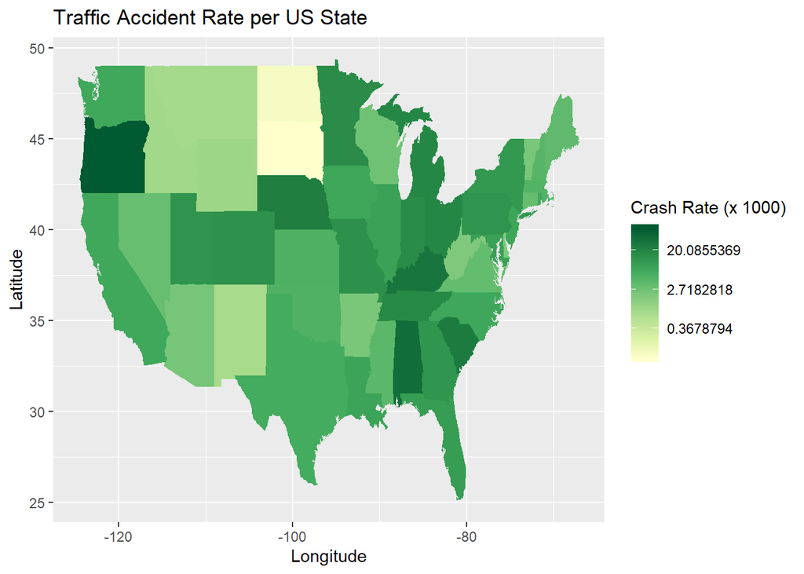

```r
states$State <- state.abb[match(states$region, stateName)]
states <- states %>% select(-'region', -'subregion')
crashByState <- crashByState %>% left_join(states, by='State')
crashByState <- crashByState %>% left_join(statePop, by='State')
crashByState %>% ggplot(aes(x=long, y=lat)) + geom_polygon(aes(group=group, fill= n / POPESTIMATE2019STATE * 1000)) + scale_fill_distiller(trans='log', palette = 'YlGn', direction = 1) + xlab("Longitude") + ylab("Latitude") + ggtitle("Traffic Accident Rate per US State") + labs(fill="Crash Rate (x 1000)")
```

We started this infographic by joining it with the population dataset for states. This was done by using a built-in R “state” function to help convert from state name to state abbreviation, as this was easier than trying to do the reverse. Next, we grouped the merged dataset by state, and created a new column showing a count of all crashes in the state. Once this was done, we were able to calculate traffic accident rate per state by dividing the total number of accidents by the state’s total population. This infographic shows how this rate differs per state. Throughout the rest of this project, we reffered back to this infographic to attempt to explain how each individual subquestion could relate back to the overall differences shown here. These subquestions were designed to help answer what gave certain states a higher (Oregon, Alabama) or lower (North Dakota, South Dakota, New Mexico) crash rate than the states around it, or what made a particular region of the United States more or less susceptible to traffic accidents.

# Questions Raised

### **1. Does the population of states and counties affect accident rates, and in the counties with the highest populations does rush hour traffic times affect accident rates?**

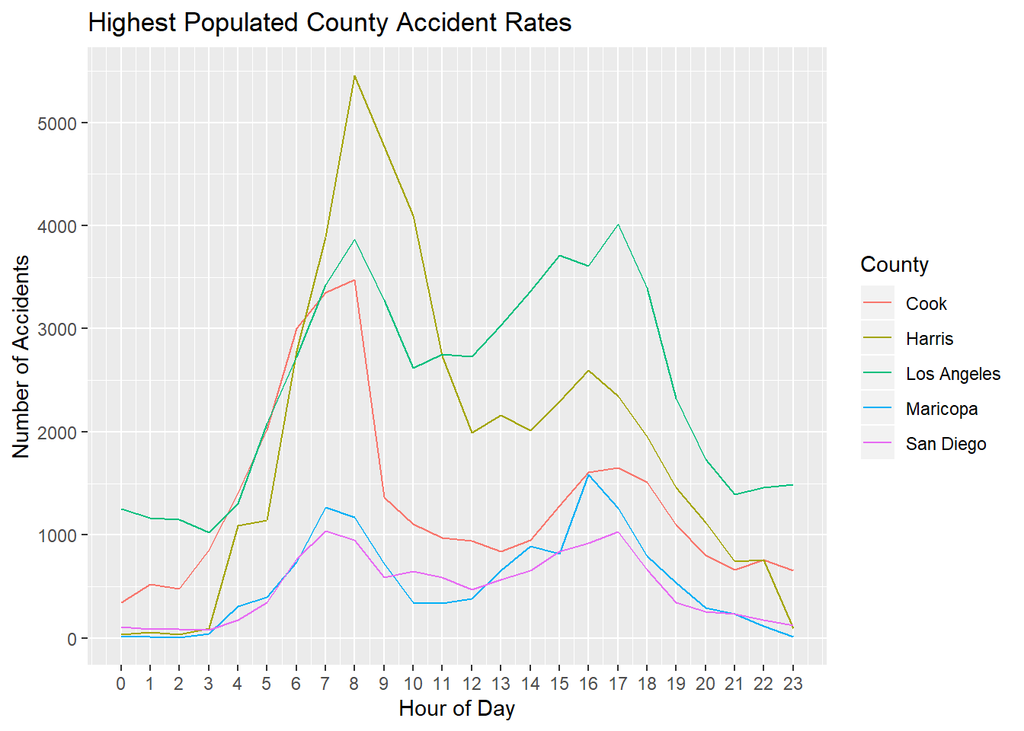

```r
q1 <- final %>% filter(County %in% c('Los Angeles','Cook','Harris','Maricopa','San Diego')) %>% group_by(Hour,County) %>% mutate(CountHour = n())
ggplot(q1, aes(x = Hour, y = CountHour)) + scale_y_continuous(breaks = seq(0, 6000, 1000),labels = function(x) format(x, scientific = FALSE)) + scale_x_continuous(breaks = seq(0, 23, 1)) + labs(title="Highest Populated County Accident Rates", x="Hour of Day", y="Number of Accidents",color="County") + geom_line(aes(color = factor(County)))
```

There is a clear spike in traffic accidents in certain times of the day. The highest rate of accidents occured from 7am to 9am and 4pm to 6pm. This is almost certainly due to people going to and from work, school, and other activities from their day. Avoiding these “rush hours” not only save the driver and passengers time, but they lower the risk of getting into an accident.

One of the most interesting observations about the graphic below is that the rush hour time periods are longer than one hour. In bigger counties, such as the five shown here, a higher population means there will be a higher traffic accident rate since there are more cars on the road. These counties aren’t just indicative of higher populated counties, but a majority of counties since most have a rush hour of some degree.

### **2. How do warmer states compare with colder states in traffic accident rates during the summer? Do these rates change when conditioning the data only on winter months? Is this change in rates large enough to justify that harsh winter weather conditions have a high correlation to traffic accident rates? Is winter weather causing this change?**

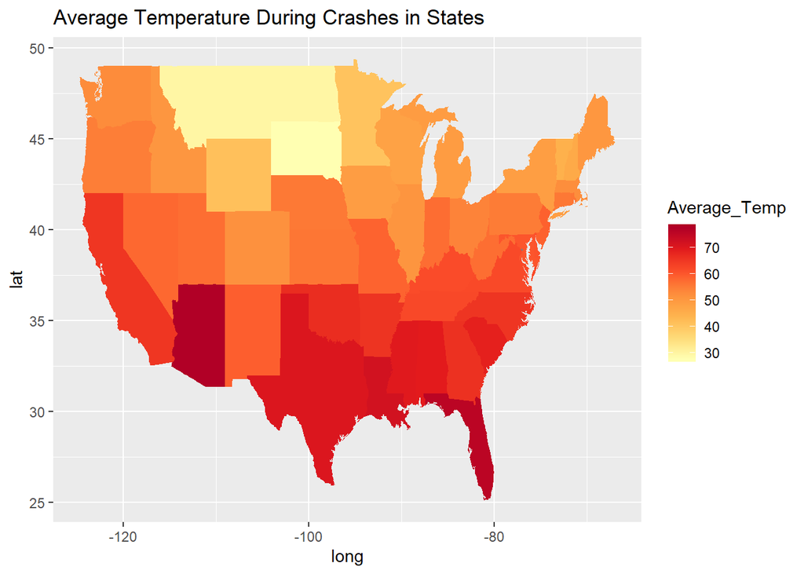

```r
#Take the top 7 coldest states and the top 7 warmest states
Temp <-final %>% group_by(State) %>% summarize(Average_Temp = mean(`Temperature(F)`))
TempChloropleth <- Temp %>% left_join(states, by='State')
TempChloropleth %>% ggplot(aes(x = long, y = lat, group = group, fill = Average_Temp)) + geom_polygon() + ggtitle("Average Temperature During Crashes in States") + scale_fill_distiller(palette = 'YlOrRd', direction = 1)
```

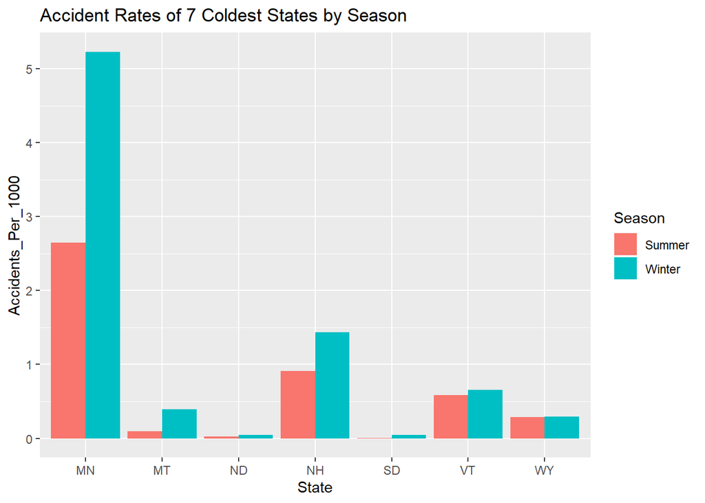

```r
Top7Hottest <- Temp %>% arrange(desc(Average_Temp))  %>% head(7)
Top7Coldest <- Temp %>% arrange(Average_Temp) %>% head(7)
Temp1 <-final %>% mutate(Month = month(Date))
Summer <- Temp1 %>% filter(Month %in% c(6,7,8)) %>% group_by(State) %>% mutate(Number_of_Accidents_State = n(), Average_Temp_in_Season = mean(`Temperature(F)`))
Winter <- Temp1 %>% filter(Month %in% c(12,1,2)) %>% group_by(State) %>% mutate(Number_of_Accidents_State = n(), Average_Temp_in_Season = mean(`Temperature(F)`))
StatePopulation <- final %>% select(POPESTIMATE2019, State, County) %>% distinct(County, .keep_all = TRUE) %>% group_by(State) %>% summarize(State_Population = sum(POPESTIMATE2019))
Summer <- Summer %>% left_join(statePop, by='State') %>%
  mutate(Accidents_Per_1000 = Number_of_Accidents_State/POPESTIMATE2019STATE*1000) %>%
  distinct(State, .keep_all = TRUE) %>% select(State,Accidents_Per_1000, Average_Temp_in_Season) %>%
  mutate(Temperature_Throughout_Year = if_else(State %in% Top7Coldest$State, "Coldest", if_else(State %in% Top7Hottest$State, "Hottest", "In Between"))) %>% mutate(Season = 'Summer')
Winter <- Winter %>% left_join(statePop, by='State') %>%
  mutate(Accidents_Per_1000 = Number_of_Accidents_State/POPESTIMATE2019STATE*1000) %>%
  distinct(State, .keep_all = TRUE) %>% select(State,Accidents_Per_1000, Average_Temp_in_Season) %>%
  mutate(Temperature_Throughout_Year = if_else(State %in% Top7Coldest$State, "Coldest", if_else(State %in% Top7Hottest$State, "Hottest", "In Between"))) %>% mutate(Season = 'Winter')
full <- Summer %>% full_join(Winter,by = c("State", "Accidents_Per_1000", "Average_Temp_in_Season", "Temperature_Throughout_Year", "Season"))
full$Season <- factor(full$Season)
ColdestStates <- full %>% filter(Temperature_Throughout_Year == "Coldest")
HottestStates <- full %>% filter(Temperature_Throughout_Year == "Hottest")
ColdestStates %>% ggplot(aes(x = State, y = Accidents_Per_1000, fill = Season)) + geom_bar(position= "dodge", stat = 'identity') + ggtitle("Accident Rates of 7 Coldest States by Season")
```

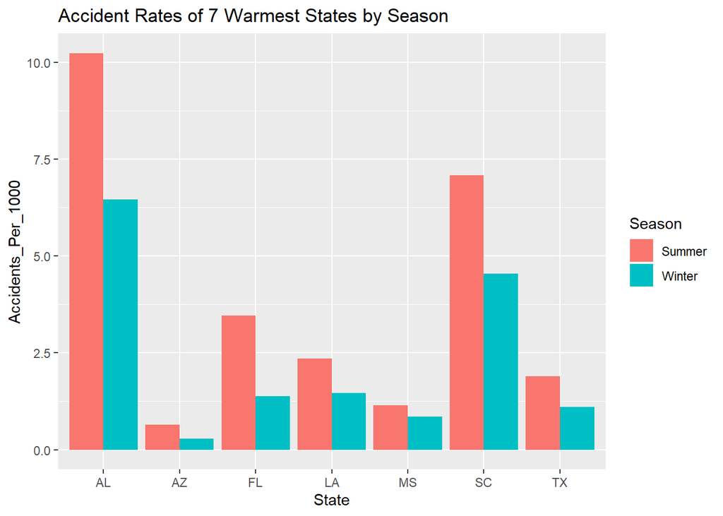

[output not shown]

```r
HottestStates %>% ggplot(aes(x = State, y = Accidents_Per_1000, fill = Season)) + geom_bar(position= "dodge", stat = 'identity') + ggtitle("Accident Rates of 7 Warmest States by Season")
```

### **3. Are traffic accidents more common in the day or night and in turn does a higher or lower latitude have any correlation to the amount of traffic accidents that occur?**

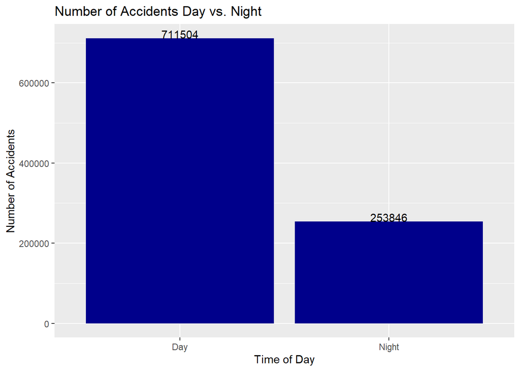

```r
JakeCrash2 <- crashData
JakeCrash2$Sunrise_Sunset <- factor(JakeCrash2$Sunrise_Sunset)
JakeCrash2 %>% group_by(Sunrise_Sunset) %>% summarize(Num_Accidents = n()) %>% ggplot(aes(x = Sunrise_Sunset, y =Num_Accidents)) + geom_bar(stat= 'identity', fill = "blue4") + geom_text(aes(label = Num_Accidents), colour = "Black", vjust = 0) + ggtitle("Number of Accidents Day vs. Night") + xlab("Time of Day") + ylab("Number of Accidents") + scale_y_continuous(breaks = seq(0, 800000, 200000),labels = function(x) format(x, scientific = FALSE))
```

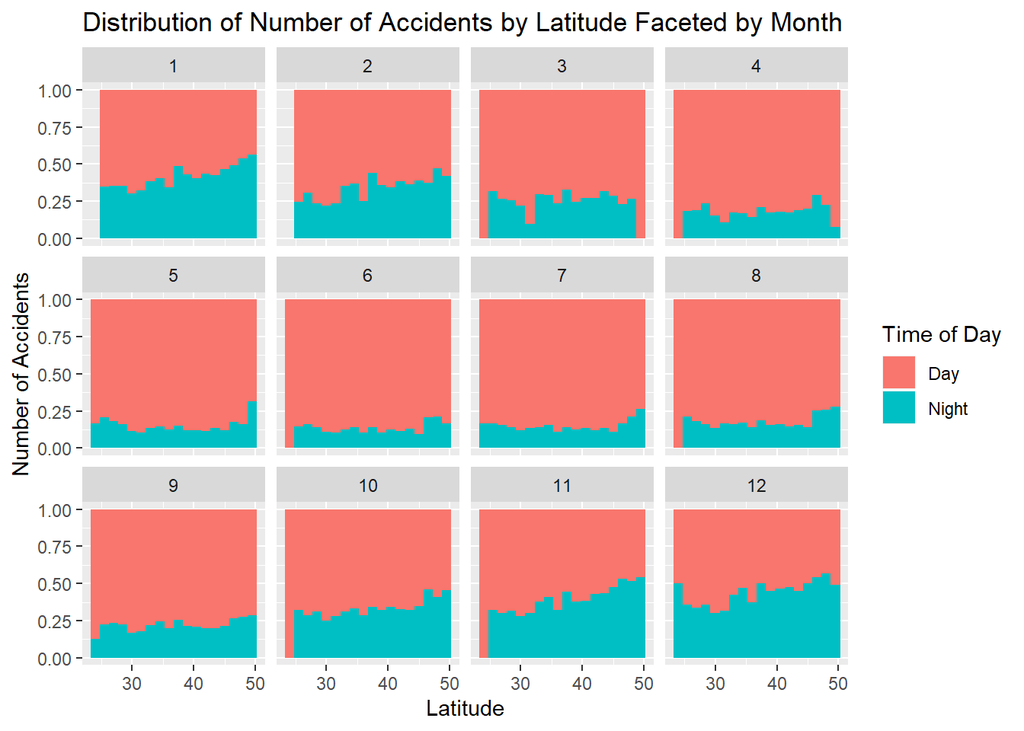

```r
#There are more accident occurences in the day than in the night
JakeCrash2 %>% mutate(Month = month(Date)) %>% ggplot(aes(x = Start_Lat, fill = Sunrise_Sunset)) + geom_histogram(position = "fill",binwidth = 1.5) + facet_wrap(~Month) + ggtitle("Distribution of Number of Accidents by Latitude Faceted by Month") + xlab("Latitude") + ylab("Number of Accidents") + labs(fill = "Time of Day")
```

To answer the question of when traffic accidents are most common we created a bar plot using ggplot showing the number of traffic accidents that occur during the day and night. To create this barplot we needed to group the data by the variable sunrise_sunset and then count the number of occurrences for each level of sunrise_sunset. This gave us a barplot that showed that traffic accidents are much more common in the day than the night. This finding did not seem to make much sense as it is assumed that night driving is much more dangerous than day driving. The reason for this confusing finding we believe is the presence of confounding variables like sleep schedules, as fewer people drive during the night because they are asleep.

Since we believe there are reasons for day accidents to be more common than night accidents other than the level of danger involved. We want to test if an increased number of nighttime hours is a reason why higher latitude (colder) states have an increased accident rate during the winter. To do this we used the ggplot histogram function to create a filled histogram that showed the proportion of accidents that occurred during the night by latitude and faceted this by month. From this visualization, we can see that during the summer months the proportion of accidents that occur during the night decreases as there are more daylight hours. During the winter months, almost half the accidents occur at night, this is because there is an increase in the number of nighttime hours. There is also a positive relationship between latitude and the proportion of night accidents that occur during the winter. This is due to higher latitudes having fewer daylight hours than lower latitudes, forcing people that live in these higher latitude states to drive at night as they have a very limited number of daylight hours. With all these observations we can conclude from our visualization that the amount of daylight hours is a reason why higher latitude (colder) states have an increased accident rate during the winter.

### **4. Show the distribution of visibility in traffic accidents in the US. What does the distribution tell us about the effects that different visibility levels have on how many traffic accidents occur?**

```r
#crashData %>% mutate(x_new = ifelse(`Visibility(mi)` > 11.5, 11.5, `Visibility(mi)`)) %>% ggplot(aes(x_new)) + geom_histogram(binwidth #= 1, col = "black", fill = "cornflowerblue") + scale_y_continuous(breaks = seq(0, 600000, 100000),labels = function(x) format(x, #scientific = FALSE)) + scale_x_continuous(breaks = seq(0, 11, 1)) + labs(title="Distribution of Visibility in Traffic Accidents in the #US",x="Visibility in Miles",y="Number of Accidents")
#This graph was used in the presentation, but has been cut here.
```

Visibility is an important factor in car accidents, however, they are not one of the biggest causes in determining an accident. This is mainly because the amount of days where the visibility is dangerously low doesn’t occur very often in a year. It appears that the default or standard distance of visibility of an accident is 10 miles. This means that on the average day of an accident it’s not because of the visibility.

Obviously avoiding low visibility is important whenever traveling since it reduces reaction time between stopping and moving. Ultimately, traveling decisions can’t be based on conditions that happen very few times in the year, therefore, it’s not needed to worry compared to other factors that would affect the crash rate more.

### **5. What are the most common weather conditions that occur during accidents? What states do these weather conditions occur at the highest rate in and are these states generally near the top of traffic accident rates when including all weather conditions?**

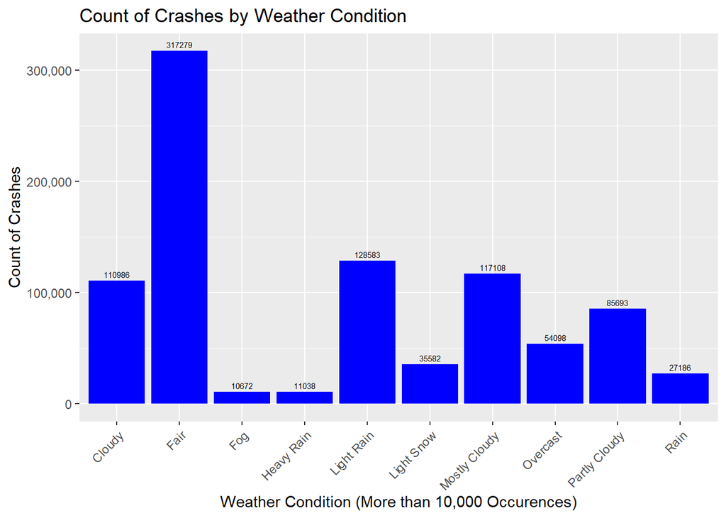

```r
crashData %>% group_by(Weather_Condition) %>% filter(n() > 10000) %>%
  ggplot(aes(x=Weather_Condition)) + geom_bar(fill='blue') +
  geom_text(stat='count', aes(label=stat(count), vjust = -.5), size=2) +
  theme(axis.text.x = element_text(angle=45, vjust=1, hjust=1)) +
  scale_y_continuous(labels=scales::comma) + xlab("Weather Condition (More than 10,000 Occurences)") +
  ylab("Count of Crashes") + ggtitle("Count of Crashes by Weather Condition")
```

```r
#This graph shows the most common weather patterns during accidents throughout the United States. I will now see how each state is affected by these weather events.
#commonWeather <- crashData %>% filter(
#        Weather_Condition == 'Cloudy' | Weather_Condition == 'Light Rain' |
#        Weather_Condition == 'Light Snow' | Weather_Condition == 'Mostly Cloudy' |
#        Weather_Condition == 'Partly Cloudy' | Weather_Condition == 'Fog' |
#       Weather_Condition == 'Heavy Rain' | Weather_Condition == 'Rain' |
#        Weather_Condition == 'Overcast')
#commonWeather <- commonWeather %>% group_by(State) %>% left_join(statePop, by='State')
#commonWeather <- commonWeather %>% mutate(n = n()) %>%
#  mutate(crashRate = n / POPESTIMATE2019STATE)
#commonWeather$Weather_Condition <-
#  factor(commonWeather$Weather_Condition,
#        levels = c("Heavy Rain", "Rain", "Light Rain", "Cloudy", "Mostly Cloudy", "Partly Cloudy", "Overcast", "Fog", "Light Snow"))
#commonWeather %>% ggplot(aes(x=State)) + coord_flip() +
#  geom_bar(aes(fill=Weather_Condition), position="fill") +
#  theme(axis.text.y = element_text(vjust=1, hjust=1, size=6)) +
#  ggtitle("Crash Percentage in Different Weather per State")

#It appears that states differ greatly in terms of how weather events affect them. North Dakota and Montana, for example, have close to or more than half of all crashes in their states during a snowy or foggy scenario.
#This graph was used in the presentation, but has been cut here.
```

Creating the first chart was very easy. We added the count of each bar to the top of each bar, since it helps show the differences between bars that are somewhat close in height.

### **6. What is the relationship between the amount of precipitation on the ground and the amount of accidents that happen? How does this relationship vary when conditioned on different types of precipitation(Snow, Sleet, Rain)?**

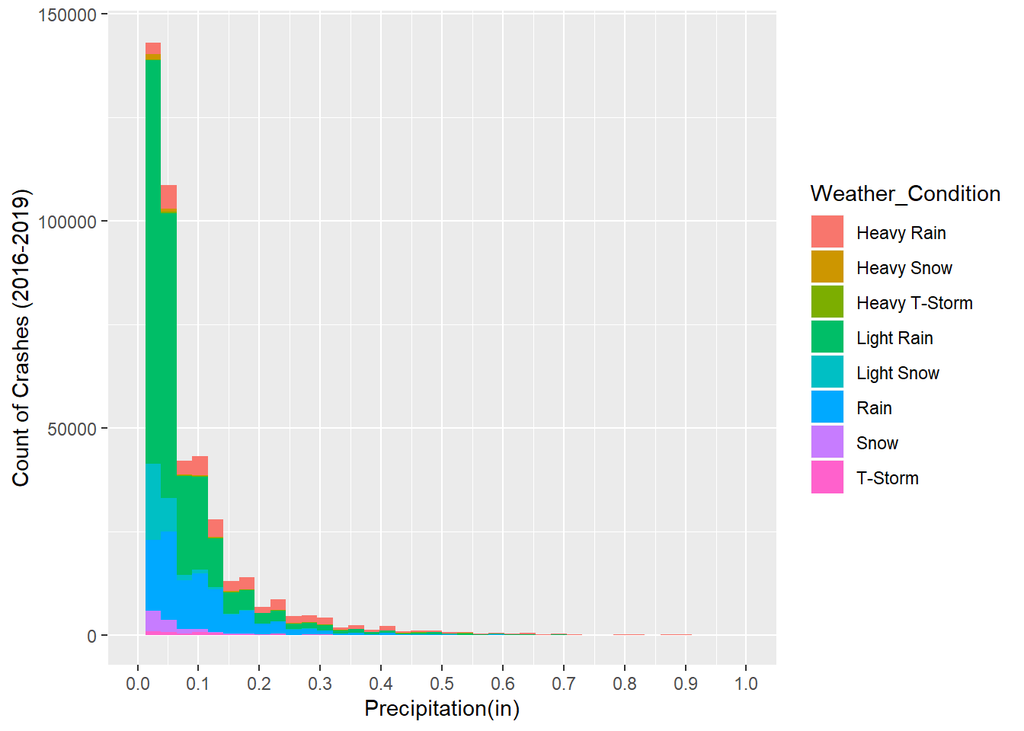

```r
precip <- final %>% filter(`Precipitation(in)` != 0.00) %>% mutate(CountHour = n())
precip <- precip %>% filter(
        Weather_Condition == 'Snow' | Weather_Condition == 'Heavy Snow' |
        Weather_Condition == 'Light Snow' | Weather_Condition == 'Light Rain' |
        Weather_Condition == 'Rain' | Weather_Condition == 'Heavy T-Storm' |
        Weather_Condition == 'Heavy Rain' | Weather_Condition == 'T-Storm' |
        Weather_Condition == 'Light T-Storm')
precip <- final %>% group_by(Weather_Condition) %>% mutate(n = n()) %>% filter(`Precipitation(in)` != 0.00)
precip <- precip %>% filter(
        Weather_Condition == 'Snow' | Weather_Condition == 'Heavy Snow' |
        Weather_Condition == 'Light Snow' | Weather_Condition == 'Light Rain' |
        Weather_Condition == 'Rain' | Weather_Condition == 'Heavy T-Storm' |
        Weather_Condition == 'Heavy Rain' | Weather_Condition == 'T-Storm' |
        Weather_Condition == 'Light T-Storm')
precip %>% ggplot(aes(x=`Precipitation(in)`, fill = Weather_Condition)) +
  geom_histogram(bins = 40) +
  scale_x_continuous(breaks = seq(0, 1,.1), lim = c(0, 1)) +
  ylab("Count of Crashes (2016-2019)")
```

After the failure to find useful information about the varying weather conditions at time of crash, we wanted to narrow in on how different amounts of precipitation in its various forms affect crashes. We created a histogram showing the counts of crashes for each amount of precipitation (in inches) on the ground, and then filled the histogram by the different types of precipitation that occured (snow, rain, etc). This was done to show the viewer how often the varying types of precipitation was shown in our dataset.

### **7. Between the 2017 and 2019 how have the amount of accidents changed over all States in the US? What States accident rate has increased the most and which has decreased the most? What may be the reason for this?**

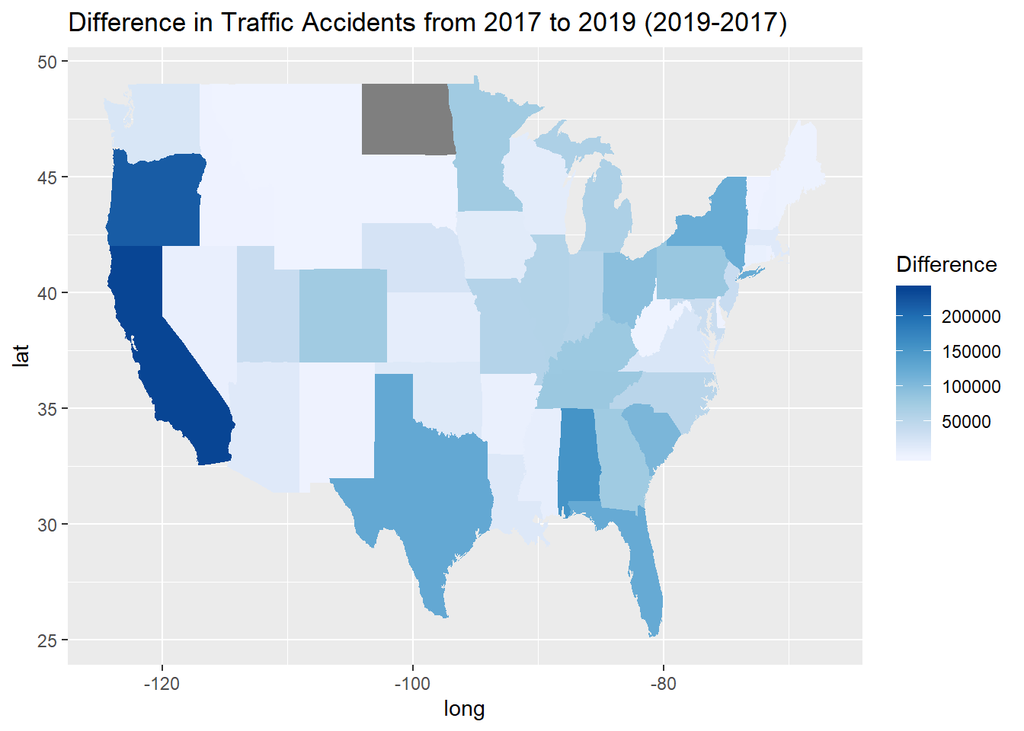

```r
dat2017 <-final %>% mutate(year = year(Date)) %>% filter(year == 2017) %>% group_by(State) %>% summarize(Occurences_State_2017 = n())
dat2019 <- final %>% mutate(year = year(Date)) %>% filter(year == 2019) %>% group_by(State) %>% summarize(Occurences_State_2019 = n())
Counties <- map_data("county") %>% mutate(County = subregion) %>% select(-subregion)
both <- full_join(dat2017, dat2019, by='State')
both <- both %>% mutate(Difference = Occurences_State_2019 - Occurences_State_2017)
difference <- left_join(both, states, by='State')
difference %>% ggplot(aes(x = long, y = lat, group = group, fill = Difference)) + geom_polygon() + scale_fill_distiller(palette = 'Blues',direction =1 ) + ggtitle("Difference in Traffic Accidents from 2017 to 2019 (2019-2017)")
```

For this question, we once again made a chloropleth map. This time, however, it was in an attempt to see how traffic accident rates changed from 2017 to 2019. We created two different dataframes, one for the starting year of 2017 and one for the ending year of 2019. We joined with state data to make a chloropleth map, with a column to show 2019 crashes minus 2017 crashes. We chose the blue theme and reversed the direction once we noticed that every state increased. This transition from white to blue worked better for this, as opposed to one color to another, as it is easier on the eyes of the viewer.

# Member Roles:

Charlie helped clean the datasets, and was the one in charge of joining the varying population dataframes with the car accident data. Once this join was done, he grouped the crash data by state, and created a new column giving the total count of crashes in each state. This allowed everyone to easily calculate crash rates by simply taking the number of crashes column and divide it by the total state population column. He was also in charge of creating the feature infographic shown above, along with answering a question and creating a bar chart regarding frequency of weather conditions at the time of a crash. He also did the outside research present in question 7. Charlie also helped edit and oversee the creation of the project report. Charlie recorded us while we gave the presentation and then he submitted it to Box. Lastly, he helped answer questions from the class after giving the presentation.

Jacob was in charge of formulating the questions raised for the project. His main goal was to create a main question that could be answered using the data set and then create sub questions that could help answer the main question, as this would make the presentation more cohesive. Jacob was also in charge of answering sub questions 2, 3, and 7 by using data wrangling and visualization techniques. He created the outline for the powerpoint, made sure it contained necessary information, and was responsible for quality control of the slides. Jacob was also solely responsible for the creation of slides over questions 2 and 3, and also contributed to the creation of the slides for question 7. During the presentation, Jacob presented his findings for questions 2 and 3, and answered questions during the live Q and A afterwards. During the creation of the report he typed the paragraphs for questions 2, 3, and explained his findings on these questions.

Juan took care of our precipitation question, several slides and some of the writing of the report. The precipitation question was a bit tricky at first because as we created the question we visualized a completely different graph that we would use and time was spent attempting to make that work; that idea was scrapped and we moved on to our current graph. Since the precipitation is measured in inches, the amount of inches increase every hundredth after the decimal point, so we had to play around with bins, their size, setting limits as well as limiting the weather types to be analyzed as the data set has over 120 weather types.

Cole was the project leader which involved communicating with Professor Dai and the TA. The role also included scheduling meetings and making sure everything went smoothly. When it came to the presentation, he worked on the first and fourth questions of the project regarding rush hour times and visibility. Along with creating and presenting these slides, the introduction slides such as the background, selecting data, cleaning data, and variables used. He contributed along with his other teammates to write some of the challenges faced, room for improvement, and ultimate conclusion of the analysis. Cole wrote and organized the outline of the report as well. In particular, he wrote his questions that he presented before and contributed greatly in the background, exploratory analysis, and conclusion paragraphs.

# Conclusion:

There are many factors that go into accidents. Some are more important than others, but they all must be looked at. This ultimately leads us to one question. What affects crash rate the most, and what affects crash rate the least?

# Works Cited

‘Horrific summer’ pushes Oregon’s traffic fatalities up. (2018, September 20). oregonlive. https://www.oregonlive.com/commuting/2018/09/horrific_summer_pushes_oregons.html

State Population Totals. (n.d.). US Census Bureau. https://www2.census.gov/programs-surveys/popest/datasets/2010-2019/state/

States with the worst drivers 2019 – SmartAsset. (2019, June 27). SmartAsset. https://smartasset.com/checking-account/states-worst-drivers-2019

US Accidents. (n.d.). Kaggle: Your Machine Learning and Data Science Community. https://www.kaggle.com/sobhanmoosavi/us-accident

US Census Bureau. (2020, March 26). County population totals: 2010-2019. The United States Census Bureau. https://www.census.gov/data/tables/time-series/demo/popest/2010s-counties-total.html